# Lab 2, Team Analysis

Brandon Rouse, Sam Reinart

2/17/2021

## Searching for the Best Chocolates

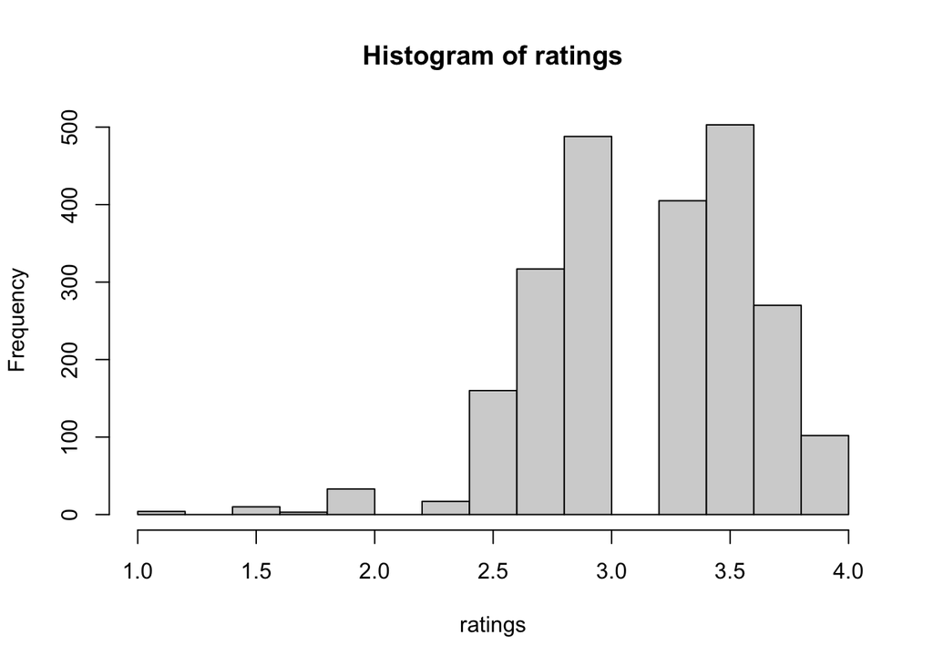

```r
ratings <- choco$Rating
hist(ratings)
```

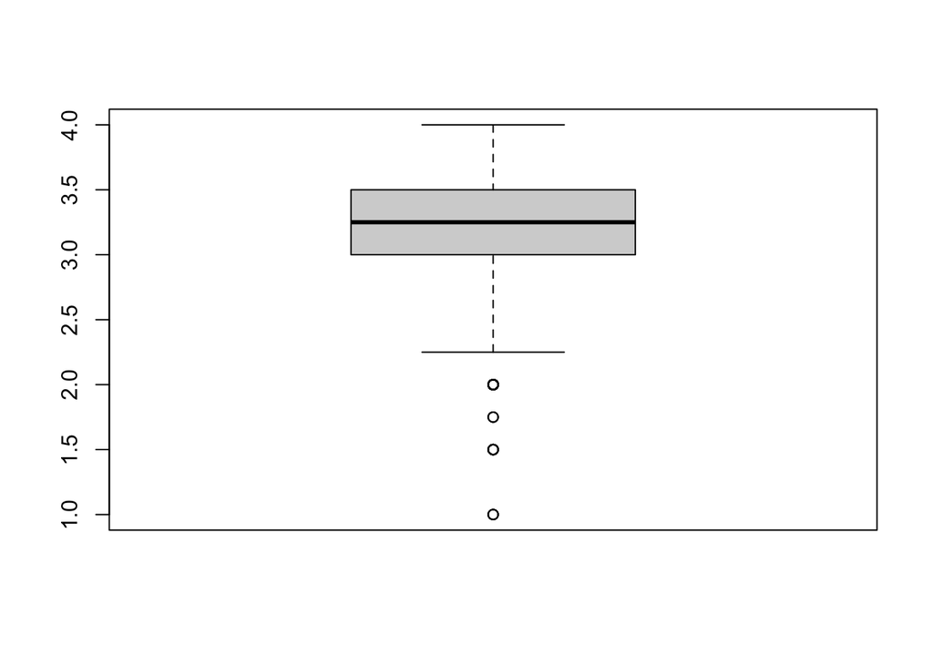

```r
boxplot(ratings)
```

As you can see from the histogram, most of the chocolate bars have a rating between 2.75 and 3.75. From the boxplot shows that the median rating is around 3.25. There are a few outliers with low ratings on the boxplot. The histogram tells us that there are around 50 chocolate bars with ratings of 2 or less. The distribution is left-skewed, bimodal, and asymmetric. There are also no data points with a perfect 5.0 rating.

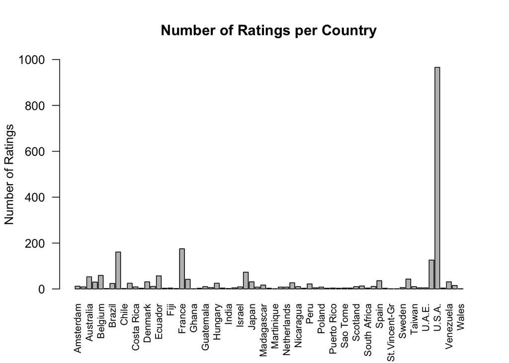

```r
locationDF <- count(choco, Location)
locationCount <- setNames(as.integer(locationDF$n), substr(locationDF$Location, 1, 13))
barplot(locationCount, las=2, cex.names=0.8, ylim=c(0,1000), ylab = "Number of Ratings", main = "Number of Ratings per Country")
```

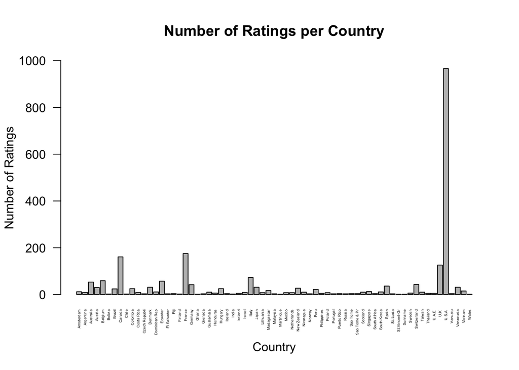

```r
barplot(locationCount, las=2, cex.names=0.3, ylim=c(0,1000), xlab = "Country", ylab = "Number of Ratings", main = "Number of Ratings per Country")
```

A large majority of the ratings were made for companies located in the United States. This is likely due to the fact that there are a lot of chocolate companies based in the U.S. The next closest countries are France and Canada. The rest of the countries have very few ratings, likely because they have much fewer chocolate companies. This is most likely due to the fact of convenience. Chocolates from a location that are easier to obtain will increase the number of ratings for that location.

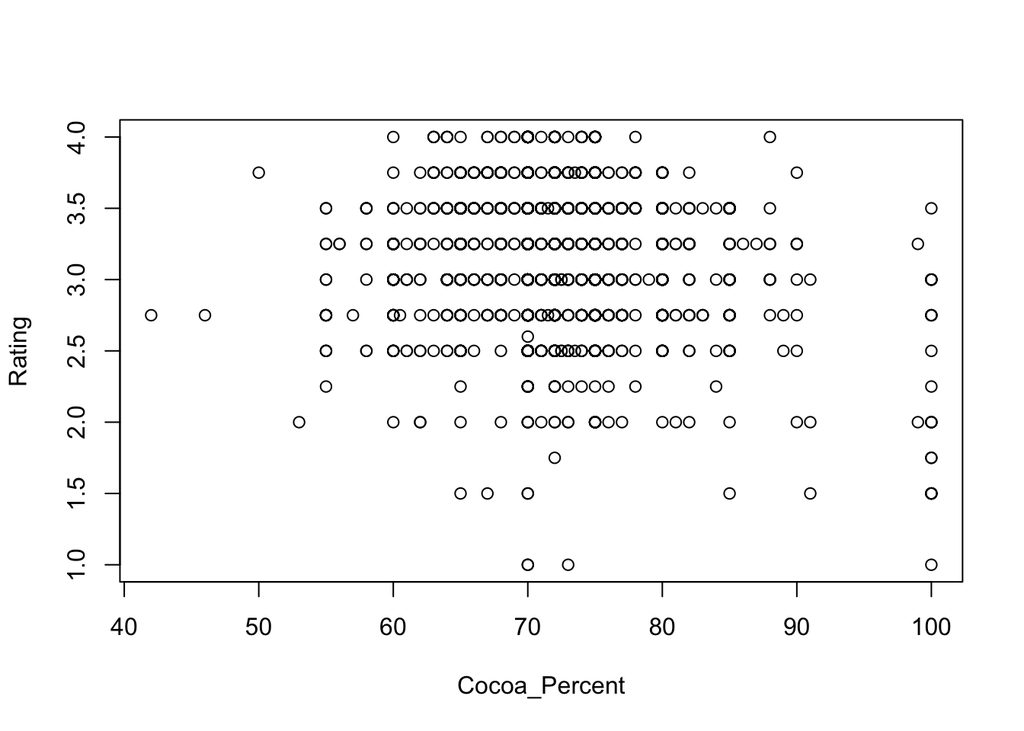

```r
cocoaRatings <- choco[c("Cocoa_Percent", "Rating")]
plot(cocoaRatings)
```

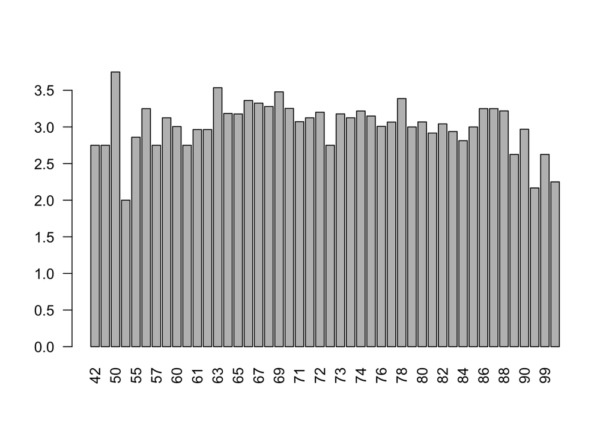

```r
cocoaMeans <- aggregate(Rating ~ Cocoa_Percent, cocoaRatings, mean)
cocoaMeansV <- setNames(cocoaMeans$Rating, cocoaMeans$Cocoa_Percent)
barplot(cocoaMeansV, las=2)
```

```r
cor(choco$Cocoa_Percent,choco$Rating)
```

```
## [1] -0.1510178
```

We can see that these two variables have a negative correlation with each other. This means that when one goes up, the other goes down. We can use this to imply that when cocoa percentage goes up, rating goes down. This correlation coefficient is relatively small though, with a value of only -0.151. This means that these two variables have a weak correlation strength.  
Using a scatterplot for this problem is not a good choice for visualization here because the values for `rating` repeat themselves for all different percentages of cocoa. The graph shows no linear relationship and the points are straight lines horizontally with each other. This makes it very hard to see the relationship between the two variables. However, after taking the average score of each cocoa percentage and plotting it using a bar plot, we can see that there does not appear to be a direct relationship between the rating of chocolate and its cocoa percentage.

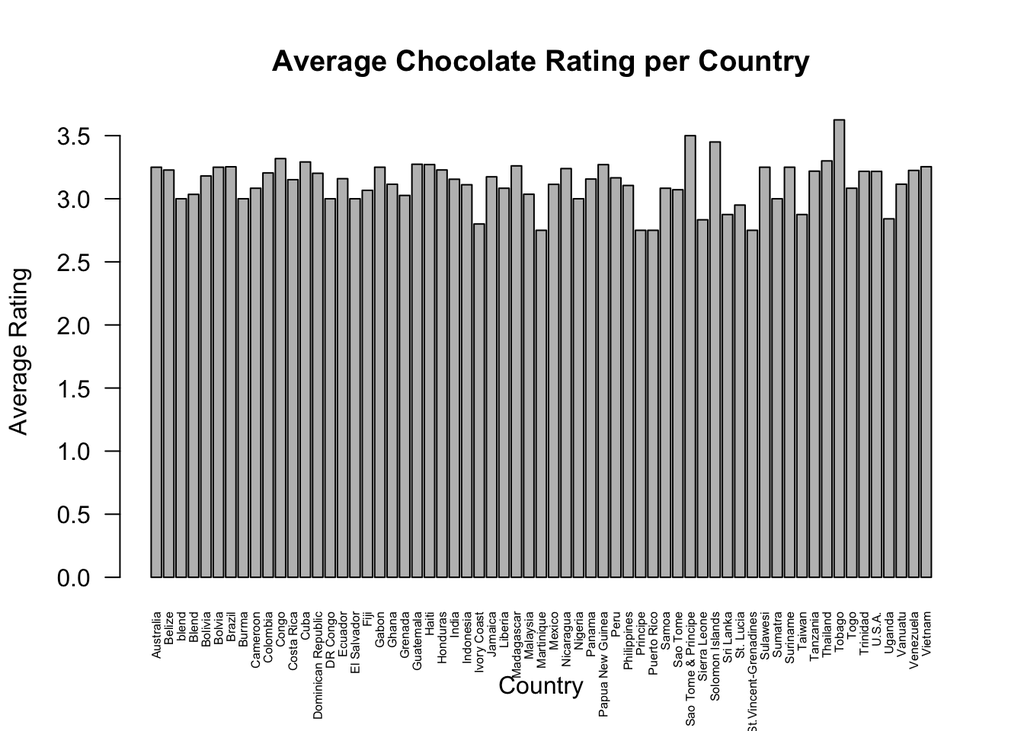

```r
originRatings <- choco[c("Bean_Origin", "Rating")]
originMeans <- aggregate(Rating ~ Bean_Origin, originRatings, mean)
originMeansV <- setNames(originMeans$Rating, originMeans$Bean_Origin)
barplot(originMeansV, las=2, cex.names=0.5, xlab = "Country", ylab = "Average Rating", main = "Average Chocolate Rating per Country")
```

```r
head(originMeans[order(originMeans$Rating), ])
```

```
##              Bean_Origin   Rating
## 32            Martinique 2.750000
## 40              Principe 2.750000
## 41           Puerto Rico 2.750000
## 49 St.Vincent-Grenadines 2.750000
## 27           Ivory Coast 2.800000
## 45          Sierra Leone 2.833333
```

```r
head(originMeans[order(-originMeans$Rating), ])
```

```
##            Bean_Origin   Rating
## 56              Tobago 3.625000
## 44 Sao Tome & Principe 3.500000
## 46     Solomon Islands 3.450000
## 11               Congo 3.318182
## 55            Thailand 3.300000
## 13                Cuba 3.291667
```

There doesn’t seem to be a lot of variation in the ratings of beans, as seen in the barplot. Many of the countries from which the highest and lowest rated beans were in the Caribbean and near Africa according to the sorted data frame. However, two countries that produce some of the highest rated beans, Thailand and the Solomon Islands, break this trend since they are located in Asia and Oceania.

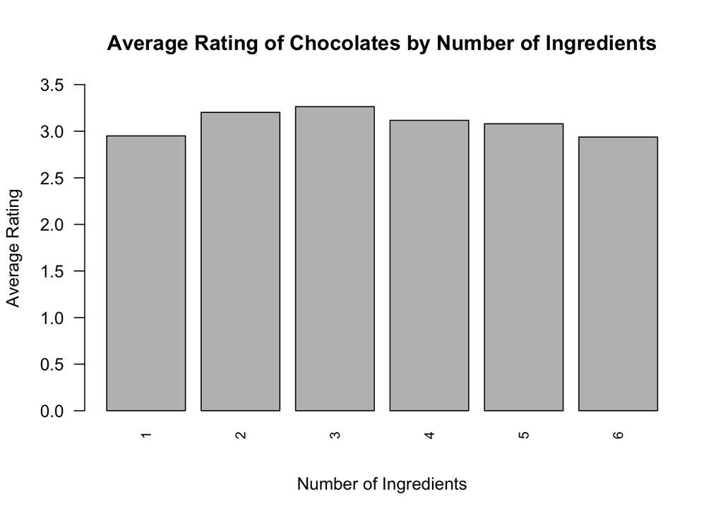

```r
numIngredientsRatings <- choco[c("Ingredients", "Rating")]
numIngredientsRatings$Num_Ingredients <- with(numIngredientsRatings, as.numeric(substr(Ingredients, 1, 1)))
numIngredientsRatings <- numIngredientsRatings[,c("Num_Ingredients", "Rating")]
numMeans <- aggregate(Rating ~ Num_Ingredients, numIngredientsRatings, mean)
numMeansV <- setNames(numMeans$Rating, numMeans$Num_Ingredients)
barplot(numMeansV, las=2, cex.names=0.8, ylim = c(0,3.5), xlab = "Number of Ingredients", ylab = "Average Rating", main = "Average Rating of Chocolates by Number of Ingredients")
```

```r
cor(numMeans$Rating, numMeans$Num_Ingredients, method="spearman")
```

```
## [1] -0.3714286
```

We decided to analyze the data to see if the number of ingredients has an effect on the rating a chocolate bar receives. The bar plot shows us that chocolate containing 2 or 3 ingredients has the highest average rating, with 3 being the best. Having more or less ingredients negatively impacts the score. The correlation between the rating and the number of ingredients seems to support this, as the correlation was -0.37 which suggests a moderate correlation between the two variables.

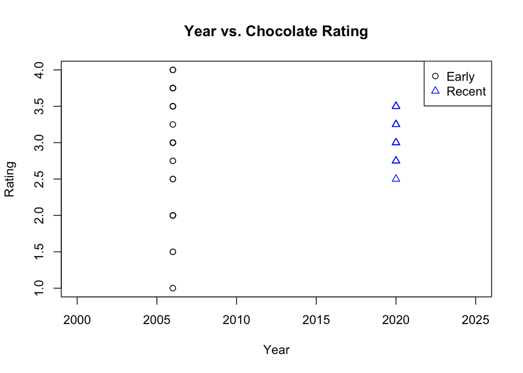

```r
library(ggplot2)
early <- choco[choco$Date == 2006,]
recent <- choco[choco$Date == 2020,]
plot(early$Date,early$Rating, xlim = range(2000:2025), xlab = 'Year', ylab = 'Rating', main = 'Year vs. Chocolate Rating')
points(recent$Date, recent$Rating, col = 'blue', pch = 2)
legend('topright',c('Early','Recent'), col = c('black','blue'),
       pch = c(1,2))
```

```r
summary(early$Rating)
```

```
##    Min. 1st Qu.  Median    Mean 3rd Qu.    Max.
##   1.000   2.562   3.000   3.004   3.688   4.000
```

```r
summary(recent$Rating)
```

```
##    Min. 1st Qu.  Median    Mean 3rd Qu.    Max.
##   2.500   3.000   3.250   3.159   3.500   3.500
```